# The outbreak of Coronavirus Disease 2019 (COVID-19): The case of South Korea

Kolor Nguyen

## Shiny App Discussion

My Shiny app shows the cumulative number of cases in each region of South Korea since January 20, when the first case in South Korea was identified. Users can choose which regions to display on the chart as well as the range of days from January 20 to March 12, which was day 55 since the first case.

South Korea has a very unique reason that led to this massive COVID-19 outbreak. Due to its proximity to China and the fact that some people who worked in Wuhan, China (where the outbreak originally started) returned home, there were some first cases in South Korea starting from January 20, 2020. The first 30 cases were from January 20 to February 16. At that time, 30 was not a big number and the situation was still under control.

However, on February 18, the massive outbreak took place because of the 31st patient in Daegu, who is also a member of Shincheonji religious organization. This patient still went to Shincheonji’s mass gatherings in the church, even when she realized she had symptoms of being infected with SARS-CoV-2. The mass gatherings involved physical contact of the church members as well as the close proximity of a lot of people in a closed space. On February 20, there had been a sudden jump of 70 new cases that were linked to the “Patient No. 31”. Until now, there are over 8000 confirmed cases in South Korea, and many of them can be traced back to the Shincheonji Church. The Korea Centers for Disease Control and Prevention (KCDC) announced that 63.5 percent of all recorded cases in the country were related to Shincheonji. There are a lot of interesting conspiracy theories about the Shincheonji organization and the Coronavirus outbreak. For example, some people think the church people were not scared of the virus because they believe they are protected by their leader, who is the second coming of Jesus Christ. Some people think Shincheonji is related to the former president Park Geun-hye and they spread the disease on purpose to make the current president, Moon Jae-in, look bad as the national elections are coming. Apart from these conspiracy theories, Shincheonji was called a cult and was blamed by a lot of people for contributing to the virus spread by refusing to provide a full list of its members to the government. This made it harder for South Korean health authorities to track the spread of outbreak as it hampered attempts by health officials to monitor and check someone who might have come into touch with anyone diagnosed with the virus. Major cities’ governments, including the capital city of Seoul, have urged national authorities to prosecute Shincheonji’s leader for potential criminal charges, including “murder through willful negligence”. However, the leader of Shincheonji refuted all accusations.

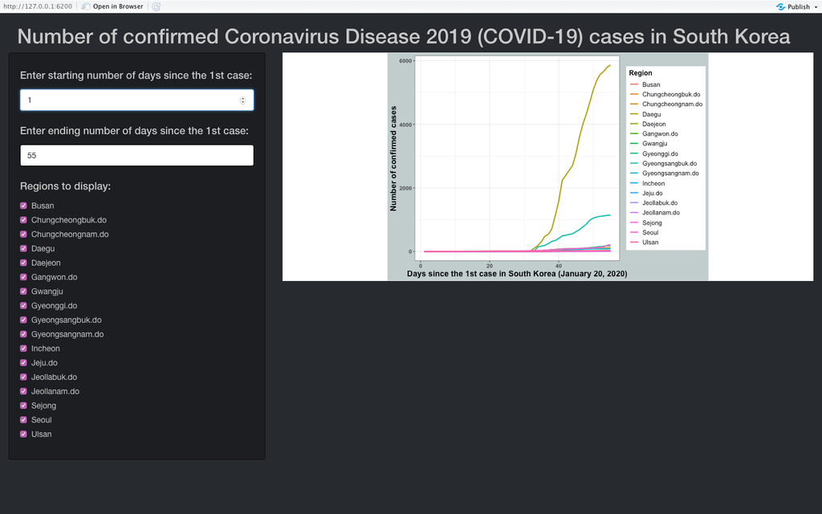

Figure 1 - Day 1 to day 55, all regions

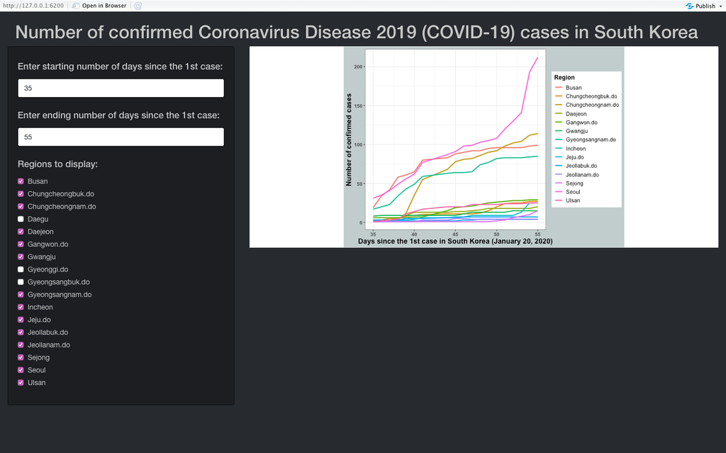

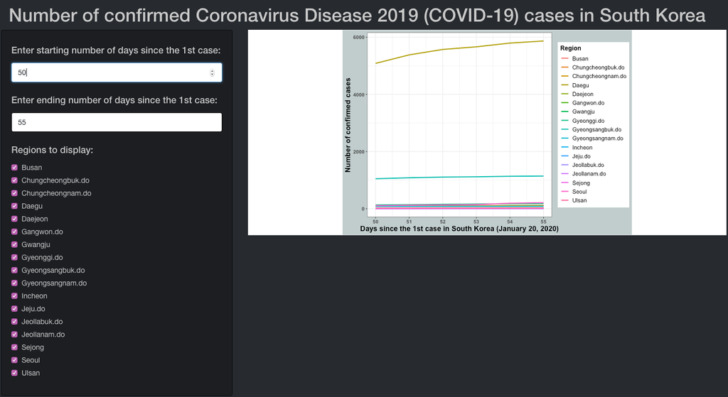

Figure 3 - The recent trend

## Technical Report

I used some data visualization, data wrangling and Shiny web app techniques to complete this project.

Regarding data visualization, I made a line chart with ggplot, colored it by different regions in South Korea. I also changed the axis title and legend’s size as well as format. I also modified the aspect ratio and background color of the plot.

Regarding data wrangling, since the dataset I used has different variables indicating the accumulated number of confirmed cases in each region, I used pivot_longer() to make a new variable called “Region” with 17 unique observations, which are the different regions of South Korea featured in the dataset. This also created the variable “Confirmed_cases” with the values originally from the 17 variables representing each location. This allowed me to color the line chart by region while still seeing the number of confirmed cases in each region every day. I also mutated a new variable all “Days_since_1st_case” to create continuous trendlines in which the number of days since the 1st case is the variable in the x-axis. I used separate() to separate the “date” into variables indicating the year, month, and day, which made it easier for me to mutate this variable.

Regarding Shiny web app techniques, I changed the theme of the app to a dark theme and followed a layout of a sidebar layout consisting of sidebar panels and the main panel. I created checkbox inputs for regions and numeric inputs for the range of days from January 20 to March 12 for users to select.

I wish there are also data for the numbers of testing, deaths, releases and negative cases for each region, but unfortunately, only country-level data of those numbers are available, not region-level. If region-level data of the numbers of testing, death, and negative cases also exist, I would add a new feature to my Shiny app which allows users to select the variable to display on the chart, and the choices would include the number of confirmed cases, negative cases, testing, death, and releases while they can still select regions to display. Since this is a new dataset, the lack of some data may happen. There is country-level data of all these aspects so I could have made an app about the Coronavirus outbreak in the whole world. However, I think a lot of people in the class may choose the same topic for their Shiny app so I want to bring something new to the discussion by focusing on South Korea, as I also have a pretty good knowledge of this country.